# Homework #3

Ximu Wang

2019/2/1

```r
library(dplyr)
```

```r
library(ggplot2)
library(glmnet)
library(pROC)
library(rsample)
library(car)
library(MASS)
library(class)
library(rpart)
library(ROCR)
library(caret)
```

#### Read and summary the data.

```r
adult <- read.csv("hw3_adult.csv")
head(adult)
```

```
##   Age         Workclass Fnlwgt  Education Education_num
## 1  39         State-gov  77516  Bachelors            13
## 2  50  Self-emp-not-inc  83311  Bachelors            13
## 3  38           Private 215646    HS-grad             9
## 4  53           Private 234721       11th             7
## 5  28           Private 338409  Bachelors            13
## 6  37           Private 284582    Masters            14
##        Marital_status         Occupation   Relationship   Race     Sex
## 1       Never-married       Adm-clerical  Not-in-family  White    Male
## 2  Married-civ-spouse    Exec-managerial        Husband  White    Male
## 3            Divorced  Handlers-cleaners  Not-in-family  White    Male
## 4  Married-civ-spouse  Handlers-cleaners        Husband  Black    Male
## 5  Married-civ-spouse     Prof-specialty           Wife  Black  Female
## 6  Married-civ-spouse    Exec-managerial           Wife  White  Female
##   Captical_gain Captial_loss Hours_per_week Native_country Salary
## 1          2174            0             40  United-States  <=50K
## 2             0            0             13  United-States  <=50K
## 3             0            0             40  United-States  <=50K
## 4             0            0             40  United-States  <=50K
## 5             0            0             40           Cuba  <=50K
## 6             0            0             40  United-States  <=50K
```

```r
summary(adult)
```

```
##       Age                    Workclass        Fnlwgt
##  Min.   :17.00    Private         :1381   Min.   :  19302
##  1st Qu.:28.00    Self-emp-not-inc: 155   1st Qu.: 118497
##  Median :38.00    Local-gov       : 135   Median : 179436
##  Mean   :38.86    ?               : 123   Mean   : 190920
##  3rd Qu.:48.00    Self-emp-inc    :  77   3rd Qu.: 241038
##  Max.   :90.00    State-gov       :  77   Max.   :1033222
##                  (Other)          :  51
##          Education   Education_num                  Marital_status
##   HS-grad     :670   Min.   : 1.00    Divorced             :274
##   Some-college:425   1st Qu.: 9.00    Married-AF-spouse    :  2
##   Bachelors   :342   Median :10.00    Married-civ-spouse   :932
##   Masters     :113   Mean   :10.11    Married-spouse-absent: 27
##   Assoc-voc   : 85   3rd Qu.:13.00    Never-married        :649
##   11th        : 81   Max.   :16.00    Separated            : 49
##  (Other)      :283                    Widowed              : 66
##             Occupation           Relationship                  Race
##   Prof-specialty :253    Husband       :810    Amer-Indian-Eskimo:  16
##   Exec-managerial:245    Not-in-family :547    Asian-Pac-Islander:  59
##   Craft-repair   :239    Other-relative: 41    Black             : 221
##   Sales          :229    Own-child     :283    Other             :   9
##   Adm-clerical   :221    Unmarried     :207    White             :1694
##   Other-service  :216    Wife          :111
##  (Other)         :596
##       Sex       Captical_gain    Captial_loss     Hours_per_week
##   Female: 628   Min.   :    0   Min.   :   0.00   Min.   : 1.00
##   Male  :1371   1st Qu.:    0   1st Qu.:   0.00   1st Qu.:40.00
##                 Median :    0   Median :   0.00   Median :40.00
##                 Mean   : 1068   Mean   :  93.31   Mean   :40.59
##                 3rd Qu.:    0   3rd Qu.:   0.00   3rd Qu.:45.00
##                 Max.   :99999   Max.   :2415.00   Max.   :99.00
##
##         Native_country    Salary
##   United-States:1805    <=50K:1500
##   ?            :  39    >50K : 499
##   Mexico       :  34
##   Philippines  :   9
##   Canada       :   8
##   Germany      :   8
##  (Other)       :  96
```

#### Handle missing values.

```r
sum(is.na(adult$Age))
```

```
## [1] 0
```

```r
sum(is.na(adult$Salary))
```

```
## [1] 0
```

```r
sum(is.na(adult$Workclass))
```

```
## [1] 0
```

```r
sum(is.na(adult$Fnlwgt))
```

```
## [1] 0
```

```r
sum(is.na(adult$Education))
```

```
## [1] 0
```

```r
sum(is.na(adult$Education_num))
```

```
## [1] 0
```

```r
sum(is.na(adult$Marital_status))
```

```
## [1] 0
```

```r
sum(is.na(adult$Occupation))
```

```
## [1] 0
```

```r
sum(is.na(adult$Relationship))
```

```
## [1] 0
```

```r
sum(is.na(adult$Race))
```

```
## [1] 0
```

```r
sum(is.na(adult$Sex))
```

```
## [1] 0
```

```r
sum(is.na(adult$Captical_gain))
```

```
## [1] 0
```

```r
sum(is.na(adult$Captial_loss))
```

```
## [1] 0
```

```r
sum(is.na(adult$Hours_per_week))
```

```
## [1] 0
```

```r
sum(is.na(adult$Native_country))
```

```
## [1] 0
```

#### Recode the values.

```r
adult[, c("Workclass", "Education", "Marital_status", "Occupation", "Relationship", "Race", "Sex", "Native_country")] <- lapply(adult[, c("Workclass", "Education", "Marital_status", "Occupation", "Relationship", "Race", "Sex", "Native_country")], as.numeric)
adult$Salary <- recode(adult$Salary, " ' >50K'=1;else=0 ")
adult$Salary <- as.numeric(levels(adult$Salary)[adult$Salary])
table(adult$Salary)
```

```
##
##    0    1
## 1500  499
```

#### Split the dataset.

```r
set.seed(1)
adult_train_test_split <- initial_split(adult, prop = 0.8)
train_tbl <- training(adult_train_test_split)
test_tbl <- testing(adult_train_test_split)
```

## Question #1

#### logistic regression

```r
adult_glm <- glm(Salary ~ Age + Workclass + Fnlwgt + Education + Education_num + Marital_status + Occupation + Relationship + Race + Sex + Captical_gain + Captial_loss + Hours_per_week + Native_country, family = binomial, data = train_tbl)
summary(adult_glm)
```

```
##
## Call:
## glm(formula = Salary ~ Age + Workclass + Fnlwgt + Education +
##     Education_num + Marital_status + Occupation + Relationship +
##     Race + Sex + Captical_gain + Captial_loss + Hours_per_week +
##     Native_country, family = binomial, data = train_tbl)
##
## Deviance Residuals:
##     Min       1Q   Median       3Q      Max
## -2.6799  -0.6466  -0.3633  -0.1090   2.6386
##
## Coefficients:
##                  Estimate Std. Error z value Pr(>|z|)
## (Intercept)    -8.005e+00  9.489e-01  -8.436  < 2e-16 ***
## Age             3.542e-02  6.004e-03   5.899 3.67e-09 ***
## Workclass       1.478e-02  6.191e-02   0.239    0.811
## Fnlwgt         -4.490e-08  6.701e-07  -0.067    0.947
## Education      -2.924e-02  2.224e-02  -1.315    0.189
## Education_num   3.085e-01  3.166e-02   9.744  < 2e-16 ***
## Marital_status -2.828e-01  5.497e-02  -5.144 2.69e-07 ***
## Occupation     -5.437e-03  1.697e-02  -0.320    0.749
## Relationship   -2.633e-02  6.028e-02  -0.437    0.662
## Race            5.092e-02  9.254e-02   0.550    0.582
## Sex             1.029e+00  2.241e-01   4.592 4.39e-06 ***
## Captical_gain   2.505e-04  3.950e-05   6.341 2.28e-10 ***
## Captial_loss    5.933e-04  1.452e-04   4.086 4.39e-05 ***
## Hours_per_week  3.481e-02  6.515e-03   5.344 9.08e-08 ***
## Native_country -7.514e-03  9.871e-03  -0.761    0.447
## ---
## Signif. codes:  0 '***' 0.001 '**' 0.01 '*' 0.05 '.' 0.1 ' ' 1
##
## (Dispersion parameter for binomial family taken to be 1)
##
##     Null deviance: 1777.2  on 1599  degrees of freedom
## Residual deviance: 1289.3  on 1585  degrees of freedom
## AIC: 1319.3
##
## Number of Fisher Scoring iterations: 6
```

We can see “Age”, “Education_num”, “Marital_status”, “Sex”, “Captical_gain”, “captial_loss” and “Hours_per_week” are significient features. So we use them to do feature selection.

#### Use LASSO to select features.

```r
train_vars <- train_tbl[, c(1,5,6,10,11,12,13)]
test_vars <- test_tbl[, c(1,5,6,10,11,12,13)]
train_target <- train_tbl[, c("Salary")]
test_target <- test_tbl[, c("Salary")]

lasso <- cv.glmnet(x = as.matrix(train_vars), y = train_target, alpha = 1, family = "binomial")
coef(lasso, s = "lambda.min")
```

```
## 8 x 1 sparse Matrix of class "dgCMatrix"
##                            1
## (Intercept)    -8.2673817393
## Age             0.0349995793
## Education_num   0.2977048613
## Marital_status -0.2736522636
## Sex             1.0452866104
## Captical_gain   0.0002294833
## Captial_loss    0.0005675138
## Hours_per_week  0.0337935309
```

We can see that the coefficients of “Captical_gain” and “Captial_loss” are too samll compared with other coefficients, so we discard these two features. And “Sex” is the most important variable, because it’s coefficient bigger than 1.

#### The final logistic regression model

```r
train_vars <- train_tbl[, c(1,5,6,10,13)]
test_vars <- test_tbl[, c(1,5,6,10,13)]

log_glm <- glm(Salary ~ Age + Education_num + Marital_status + Sex + Hours_per_week, family = binomial, data = train_tbl[, c(1,5,6,10,13,15)])
```

#### KNN model

```r
nearest3 <- knn(train = train_vars, test = test_vars, cl = train_target, k = 3, prob = TRUE)
nearest3
```

```
##   [1] 0 0 1 0 0 1 0 0 0 1 1 1 1 0 0 1 0 0 1 0 0 0 0 0 1 0 0 0 0 0 0 1 0 0 0
##  [36] 0 0 0 1 1 0 0 0 1 0 0 0 1 1 0 1 0 0 0 0 0 0 0 0 0 0 0 1 0 1 0 0 0 0 0
##  [71] 0 0 1 1 0 0 0 0 0 0 0 0 0 0 0 0 0 0 0 0 0 0 0 0 0 1 0 0 0 0 0 1 0 0 1
## [106] 0 0 0 0 0 0 0 0 1 0 0 0 0 0 0 0 0 0 0 0 0 0 1 1 0 0 1 0 0 0 1 0 0 0 0
## [141] 0 0 0 0 1 0 0 0 0 1 0 0 0 0 0 0 0 0 0 0 1 0 0 1 0 0 1 0 0 0 0 0 0 0 1
## [176] 0 0 1 0 0 0 0 0 0 0 0 0 1 0 1 1 0 1 1 0 0 0 0 0 0 0 0 1 0 0 0 1 0 0 1
## [211] 1 0 0 1 0 0 0 1 0 0 0 1 0 0 1 0 0 0 0 0 0 1 0 0 1 0 1 1 0 0 0 0 1 1 0
## [246] 0 1 0 0 1 0 1 0 0 1 0 0 1 0 0 1 0 0 0 0 0 0 0 0 0 0 0 1 0 0 0 1 0 0 0
## [281] 1 0 0 0 0 0 0 0 0 0 1 0 0 0 0 0 0 0 0 1 0 0 1 0 0 0 0 0 0 0 0 0 0 0 0
## [316] 0 0 0 0 0 0 1 0 0 0 0 0 1 0 0 0 0 0 1 1 0 1 0 1 1 1 0 1 0 0 0 0 0 0 1
## [351] 0 0 1 1 0 0 0 1 0 0 0 0 0 0 0 1 0 0 0 0 0 0 0 0 0 0 1 0 1 0 1 1 0 1 1
## [386] 0 0 0 0 1 0 1 0 0 0 0 0 0 1
## attr(,"prob")
##   [1] 0.8000000 1.0000000 0.6666667 1.0000000 0.8000000 0.5000000 1.0000000
##   [8] 1.0000000 1.0000000 1.0000000 0.6666667 1.0000000 0.6666667 0.8333333
```

[output cut: 56 more lines]

## Question #2

#### Evaluate the models by using AUC

##### Logistic regression model.

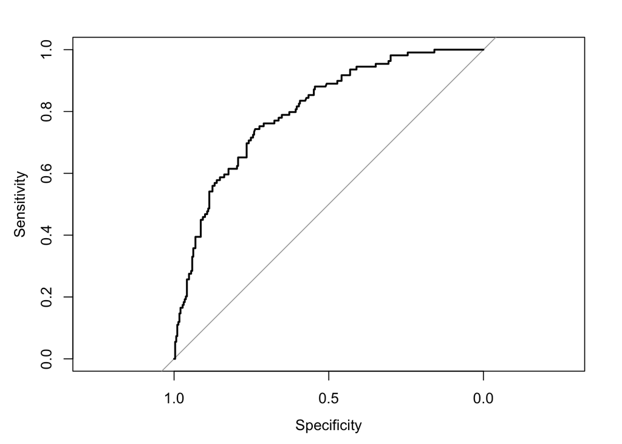

```r
log_predict <- predict(log_glm, newdata = test_tbl, type = "response")
log_roc_plot <- plot(roc(test_target, log_predict))
```

```r
log_auc <- auc(roc(test_target, log_predict))
log_auc
```

```
## Area under the curve: 0.8031
```

We can see the logistic regression model perform pretty well.

```r
ci.auc(log_auc)
```

```
## 95% CI: 0.7567-0.8496 (DeLong)
```

And the confident is also pretty high.

##### KNN model

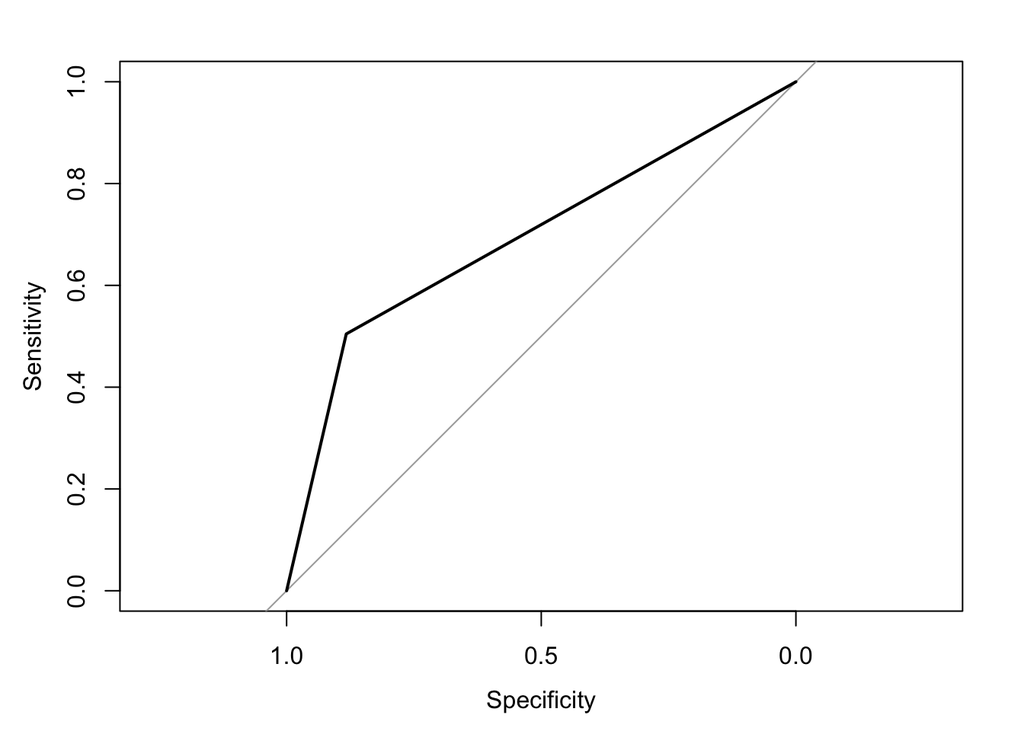

```r
knn_roc_plot <- plot(roc(test_target, as.numeric(nearest3)-1))
```

```r
knn_auc <- auc(roc(test_target, as.numeric(nearest3)-1))
knn_auc
```

```
## Area under the curve: 0.6937
```

We can see the knn model do not perform better than logistic regression model.

```r
ci.auc(knn_auc)
```

```
## 95% CI: 0.643-0.7443 (DeLong)
```

And the confident of knn model shows above.

## Question #3

#### ROC and AUC for logistic regression model

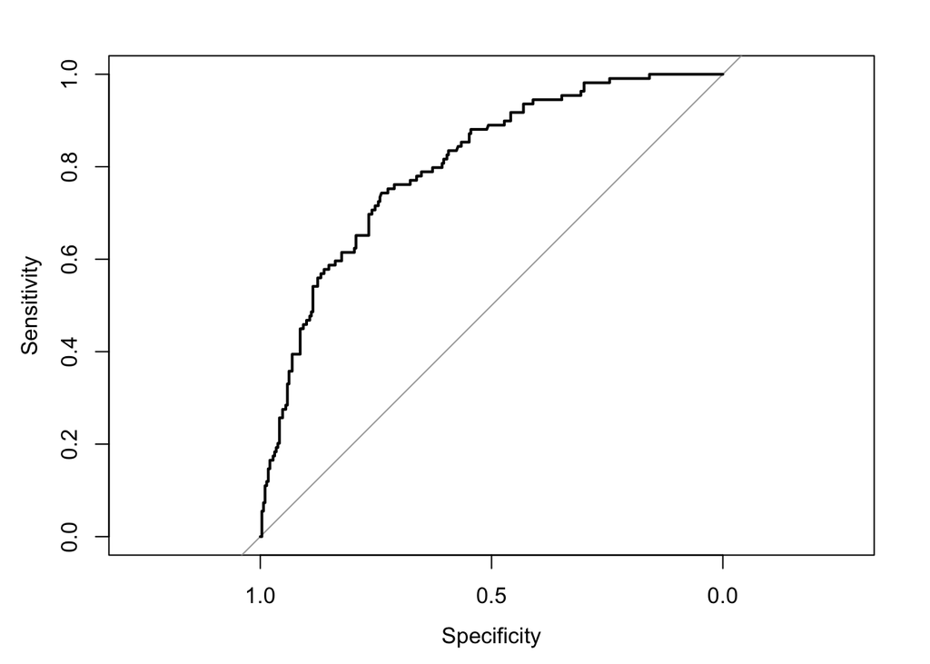

```r
log_roc_plot <- plot(roc(test_target, log_predict))
```

```r
log_auc <- auc(roc(test_target, log_predict))
log_auc
```

```
## Area under the curve: 0.8031
```

#### ROC and AUC for KNN model

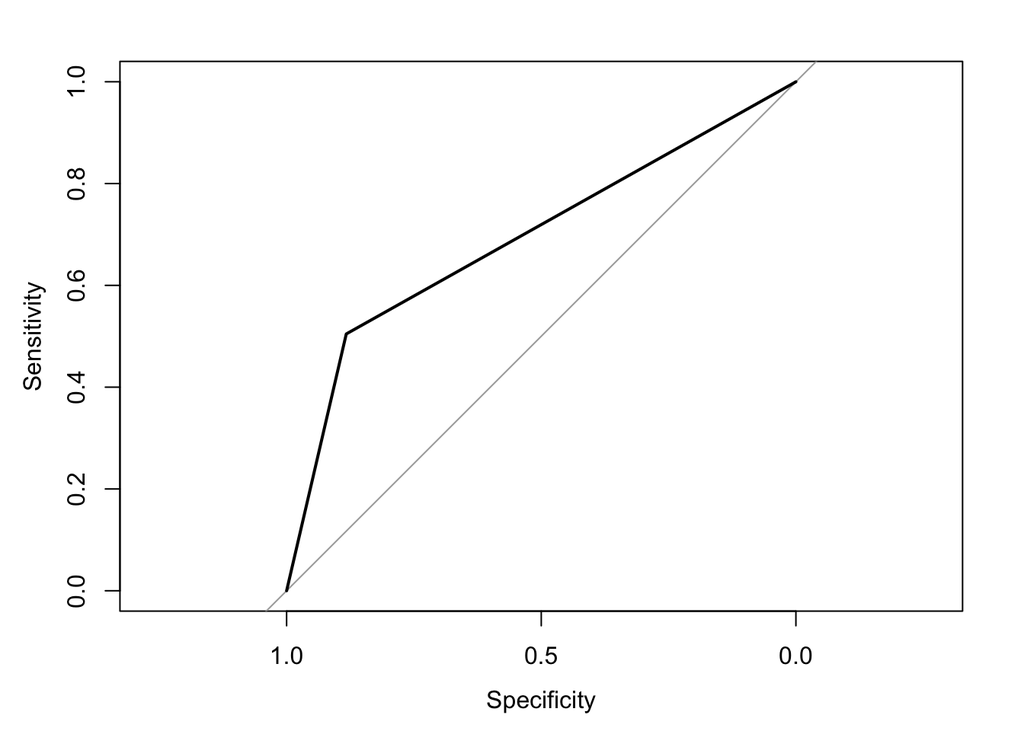

```r
knn_roc_plot <- plot(roc(test_target, as.numeric(nearest3)-1))
```

```r
knn_auc <- auc(roc(test_target, as.numeric(nearest3)-1))
knn_auc
```

```
## Area under the curve: 0.6937
```

Logistic regression model performs better in terms of AUC.